# STA 141A: Assignment 3

Kyle Guanzon | SID: 916279239

**Instructions** You may adapt the code in the course materials or any sources (e.g., the Internet, classmates, friends). In fact, you can craft solutions for almost all questions from the course materials with minor modifications. However, you need to write up your own solutions and acknowledge all sources that you have cited in the Acknowledgement section.

Failing to acknowledge any non-original efforts will be counted as plagiarism. This incidence will be reported to the Student Judicial Affairs.

We will apply clustering methods on the `penguins` dataset in the package `palmerpenguins` for Questions 1 to 6. Note that we will ignore the `species` variable to pretend that we are dealing with an unsupervised learning problem. With the `species` available, this will become a classification problem.

1. Briefly summarize the `penguins` data set. In addition to basic description of the dataset (sample size, variables, background), please be sure to read the background of this data set and provide proper citation to this data set.

```r
#Obtained from ChatGPT
# Load the penguins dataset
data("penguins")

# Display the structure of the dataset
str(penguins)
```

```
## tibble [344 × 8] (S3: tbl_df/tbl/data.frame)
##  $ species          : Factor w/ 3 levels "Adelie","Chinstrap",..: 1 1 1 1 1 1 1 1 1 1 ...
##  $ island           : Factor w/ 3 levels "Biscoe","Dream",..: 3 3 3 3 3 3 3 3 3 3 ...
##  $ bill_length_mm   : num [1:344] 39.1 39.5 40.3 NA 36.7 39.3 38.9 39.2 34.1 42 ...
##  $ bill_depth_mm    : num [1:344] 18.7 17.4 18 NA 19.3 20.6 17.8 19.6 18.1 20.2 ...
##  $ flipper_length_mm: int [1:344] 181 186 195 NA 193 190 181 195 193 190 ...
##  $ body_mass_g      : int [1:344] 3750 3800 3250 NA 3450 3650 3625 4675 3475 4250 ...
##  $ sex              : Factor w/ 2 levels "female","male": 2 1 1 NA 1 2 1 2 NA NA ...
##  $ year             : int [1:344] 2007 2007 2007 2007 2007 2007 2007 2007 2007 2007 ...
```

```r
# Summary statistics of the dataset
summary(penguins)
```

```
##       species          island    bill_length_mm  bill_depth_mm
##  Adelie   :152   Biscoe   :168   Min.   :32.10   Min.   :13.10
##  Chinstrap: 68   Dream    :124   1st Qu.:39.23   1st Qu.:15.60
##  Gentoo   :124   Torgersen: 52   Median :44.45   Median :17.30
##                                  Mean   :43.92   Mean   :17.15
##                                  3rd Qu.:48.50   3rd Qu.:18.70
##                                  Max.   :59.60   Max.   :21.50
##                                  NA's   :2       NA's   :2
##  flipper_length_mm  body_mass_g       sex           year
##  Min.   :172.0     Min.   :2700   female:165   Min.   :2007
##  1st Qu.:190.0     1st Qu.:3550   male  :168   1st Qu.:2007
##  Median :197.0     Median :4050   NA's  : 11   Median :2008
##  Mean   :200.9     Mean   :4202                Mean   :2008
##  3rd Qu.:213.0     3rd Qu.:4750                3rd Qu.:2009
##  Max.   :231.0     Max.   :6300                Max.   :2009
##  NA's   :2         NA's   :2
```

```r
# Display the first few rows of the dataset
head(penguins)
```

```
## # A tibble: 6 × 8
##   species island    bill_length_mm bill_depth_mm flipper_length_mm body_mass_g
##   <fct>   <fct>              <dbl>         <dbl>             <int>       <int>
## 1 Adelie  Torgersen           39.1          18.7               181        3750
## 2 Adelie  Torgersen           39.5          17.4               186        3800
## 3 Adelie  Torgersen           40.3          18                 195        3250
## 4 Adelie  Torgersen           NA            NA                  NA          NA
## 5 Adelie  Torgersen           36.7          19.3               193        3450
## 6 Adelie  Torgersen           39.3          20.6               190        3650
## # ℹ 2 more variables: sex <fct>, year <int>
```

From ChatGPT: The penguins dataset is a popular dataset in the field of data science and is often used for educational purposes. It consists of data related to three species of penguins: Adélie, Chinstrap, and Gentoo. The dataset contains various physical measurements of penguins, such as bill length, bill depth, flipper length, and body mass. These measurements are used to distinguish between the different penguin species.

The background of this dataset is that it was collected by Dr. Kristen Gorman and the Palmer Station, Antarctica LTER, a Long Term Ecological Research program funded by the National Science Foundation. The data was first made available on GitHub by Allison Horst and was later included in the palmerpenguins R package.

Here’s a brief summary of the penguins dataset:

Gorman, Kristen B.; Williams, Tony D.; Fraser, William R. (2014). Ecological Sexual Dimorphism and Environmental Variability within a Community of Antarctic Penguins (Genus Pygoscelis). PLOS ONE. doi:10.1371/journal.pone.0085297

2. Create a data set with no missing values in `bill_length_mm` and `body_mass_g`. Then, create a scatterplot of `body_mass_g` v.s. `bill_length_mm`, where the observations are colored by their true species.

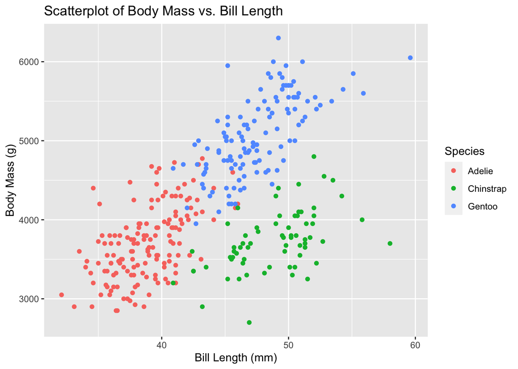

```r
#Obtained from ChatGPT
# Load the penguins dataset
data("penguins")

# Remove rows with missing values in bill_length_mm and body_mass_g
penguins_clean <- penguins[complete.cases(penguins[c("bill_length_mm", "body_mass_g")]), ]

# Create scatterplot colored by species
ggplot(penguins_clean, aes(x = bill_length_mm, y = body_mass_g, color = species)) +
  geom_point() +
  labs(x = "Bill Length (mm)",
       y = "Body Mass (g)",
       color = "Species",
       title = "Scatterplot of Body Mass vs. Bill Length")
```

3. Apply spectral clustering using the `specc()` function in package `kernlab` using the provided code. Visualize the clusters in a scatterplot. Compare the new plot with the one in Part 2. Explain your findings.

```r
#Obtained from ChatGPT
#install.packages("kernlab")
library(kernlab)
#spec.cluster<-penguins.narm %>% select(bill_length_mm, body_mass_g) %>% as.matrix() %>% specc(centers=3)

# Load the penguins dataset
data("penguins")

# Remove rows with missing values in bill_length_mm and body_mass_g
penguins_narm <- na.omit(penguins[, c("bill_length_mm", "body_mass_g")])

# Apply spectral clustering
spec_cluster <- penguins_narm %>%
  select(bill_length_mm, body_mass_g) %>%
  as.matrix() %>%
  specc(centers = 3)

# Check the cluster assignments
head(spec_cluster)
```

```
## [1] 2 2 2 2 2 2
```

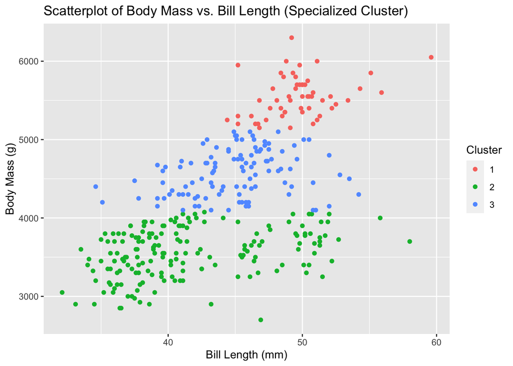

```r
# Add cluster labels to the dataset
penguins_narm$cluster <- as.factor(spec_cluster)

# Visualize the clusters in a scatterplot
ggplot(penguins_narm, aes(x = bill_length_mm, y = body_mass_g, color = cluster)) +
  geom_point() +
  labs(x = "Bill Length (mm)",
       y = "Body Mass (g)",
       color = "Cluster",
       title = "Scatterplot of Body Mass vs. Bill Length (Specialized Cluster)")
```

4. Standardize the two variables using the `scale()` function. Run spectral clustering on the standardized data, and visualize the new clusters. How do the new clusters differ from those in Part 3?

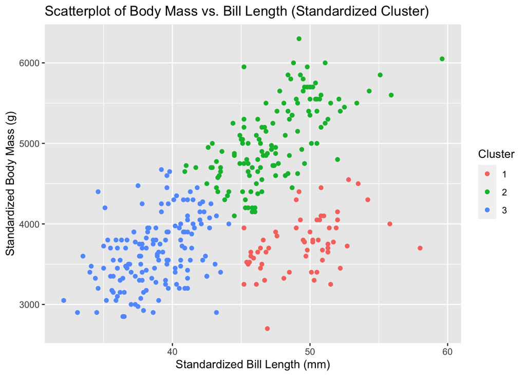

```r
#Obtained from ChatGPT

# Remove rows with missing values in bill_length_mm and body_mass_g
penguins_narm <- na.omit(penguins[, c("bill_length_mm", "body_mass_g")])

# Standardize the variables
penguins_scaled <- penguins_narm %>%
  select(bill_length_mm, body_mass_g) %>%
  scale()

# Apply spectral clustering on the standardized data
spec_cluster_scaled <- specc(penguins_scaled, centers = 3)

# Add cluster labels to the original dataset
penguins_narm$cluster <- as.factor(spec_cluster_scaled)

# Visualize the clusters in a scatterplot
ggplot(penguins_narm, aes(x = bill_length_mm, y = body_mass_g, color = cluster)) +
  geom_point() +
  labs(x = "Standardized Bill Length (mm)",
       y = "Standardized Body Mass (g)",
       color = "Cluster",
       title = "Scatterplot of Body Mass vs. Bill Length (Standardized Cluster)")
```

To compare this plot with the previous, the cluster size is more evened out, while maintaining its overall pyramid shape, indicating a better distributed cluster. Similarly, the clusters are separated without overlap. Based on the equal size, the clusters also have almost the same density.

5. Apply k-means clustering with $k=3$ on the scaled data. Visualize the clusters and comment on your findings.

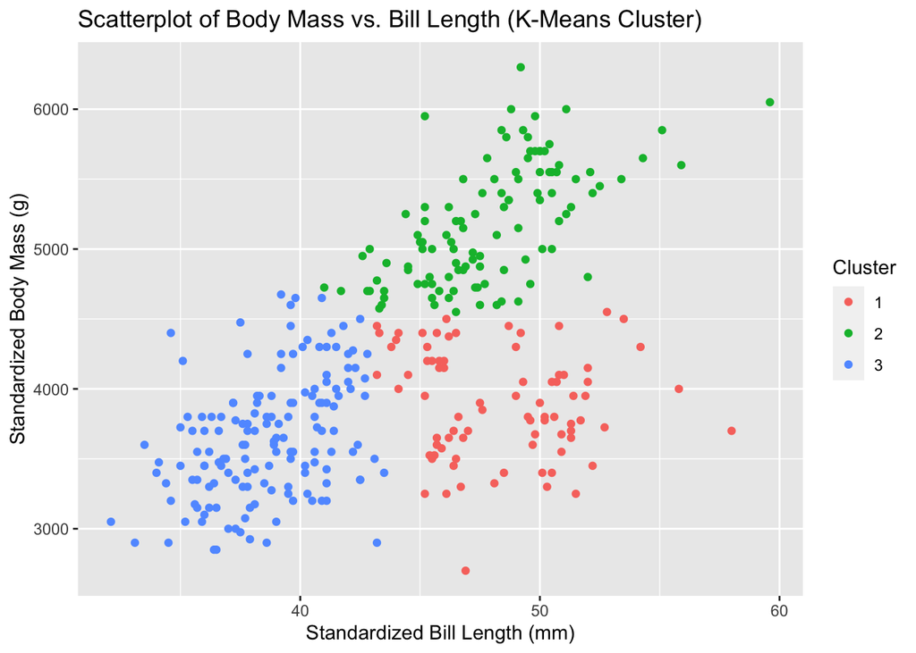

```r
#Obtained from ChatGPT

# Remove rows with missing values in bill_length_mm and body_mass_g
penguins_narm <- na.omit(penguins[, c("bill_length_mm", "body_mass_g")])

# Standardize the variables
penguins_scaled <- penguins_narm %>%
  select(bill_length_mm, body_mass_g) %>%
  scale()

# Apply k-means clustering on the scaled data
kmeans_cluster <- kmeans(penguins_scaled, centers = 3)

# Add cluster labels to the original dataset
penguins_narm$cluster <- as.factor(kmeans_cluster$cluster)

# Visualize the clusters in a scatterplot
ggplot(penguins_narm, aes(x = bill_length_mm, y = body_mass_g, color = cluster)) +
  geom_point() +
  labs(x = "Standardized Bill Length (mm)",
       y = "Standardized Body Mass (g)",
       color = "Cluster",
       title = "Scatterplot of Body Mass vs. Bill Length (K-Means Cluster)")
```

While the K-Means Cluster is almost similar to the previous plot, we are able to interpret that the K-Means cluster has the best distribution among all previous plots, meaning that the cluster sizes are about equal with one another. However, we can see that cluster 2 has sparser points, compared to the more dense clusters 1 and 3.

6. Modify the code in Part 4 to obtain 5 and 8 clusters using spectral clustering. Comment on your findings, and share your thoughts on how to select the number of clusters when the true labels are unknown.

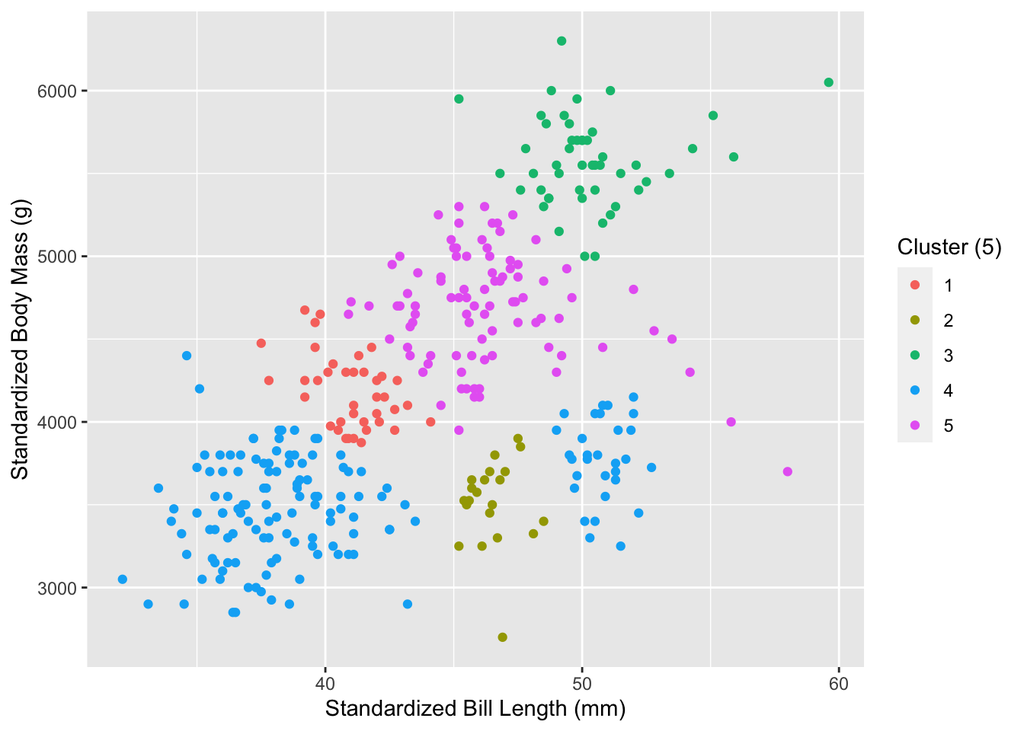

```r
#Obtained from ChatGPT
# Remove rows with missing values in bill_length_mm and body_mass_g
penguins_narm <- na.omit(penguins[, c("bill_length_mm", "body_mass_g")])

# Standardize the variables
penguins_scaled <- penguins_narm %>%
  select(bill_length_mm, body_mass_g) %>%
  scale()

# Apply spectral clustering on the standardized data with 5 clusters
spec_cluster_scaled_5 <- specc(penguins_scaled, centers = 5)

# Add cluster labels to the original dataset
penguins_narm$cluster_5 <- as.factor(spec_cluster_scaled_5)

# Visualize the clusters in a scatterplot for 5 clusters
ggplot(penguins_narm, aes(x = bill_length_mm, y = body_mass_g, color = cluster_5)) +
  geom_point() +
  labs(x = "Standardized Bill Length (mm)", y = "Standardized Body Mass (g)", color = "Cluster (5)")
```